# Data Viewer

### Overview

Last Updated: 2026-02-23

Table of Contents

Net Generation

-Net Generation (current)

-Fig. 1-G (pg. 8): Generation mix between 2005 and Current

-Figure 4-B (pg. 57): US Electricity Generation Mix 2005 and Current

-Figure 4-C (pg. 57): Midwest Electricity Generation (2018)

-Figure 4-N (pg. 63): Minnesota Electricity Generation by Source (2000-Current)

Renewables

-Fig. 1-C (pg. 4): Renewable energy vs total energy consumption 2000-Current (Note: this still uses API v.1 and will need to be updated once SEDS is live in the API)

-Figure 4-F (pg. 58): Minnesota Renewable Electricity Generation (2000-Current)

-Figure 4-G (pg. 59): Minnesota and US Renewable Electricity (2000-Current)

Renewables and Coal

-Figure 4-H (pg. 59): Minnesota and US Coal Electricity (2000-Current)

-Figure 4-I (pg. 60): Minnesota and US Carbon Intensity of Electricity (2000-Current)

-Figure 4-J (pg. 61): Economic and Seasonal Dispatch of Coal

-Figure 4-K (pg. 61): Power Generation Transition in Minnesota

Natural Gas

-Figure 4-0 (pg. 64): Henry Hub Spot Prices (2016- Current)

Consumption

-Figure 6-C (pg. 117): Minnesota Total Energy Consumption by Source

-Figure 6-D (pg. 118): Minnesota Total Energy Consumption by Source (% Btu) (2005–Current)

-Figure 6-E (pg. 118): Minnesota Total Energy Consumption by Renewable Source (2000 – Current)

Solar

-Figure 6-W (pg. 133): Minnesota Solar Additions

-Figure 6-X (pg. 134): Minnesota Cumulative Solar Capacity

Wind

-Figure 6-E (pg. 133): Minnesota Total Energy Consumption by Renewable Source (2000 – Current)

-Minnesota Cumulative Wind Capacity (New)

Additions and Retirements

-Figure 4-M (pg. 63): Minnesota Capacity Additions and Retirements (2000 – Current)

Possibilities for future development

-Resource plans from utilities -How do different demographic groups heat their homes? And is there any relationship with energy burden at the county level? Particular interest propane use and heating oil. Anywhere that doesn’t have access to utility natural gas.

### Net Generation

View Electricity Generation Data

| period | fuel_type_description | total_generation_thousand_mwh | percent_generation |
| --- | --- | --- | --- |
| 2024 | All Fuels | 58595.22155 | 1 |
| 2024 | Biomass | 1164.92473 | 0.01988088276116434 |
| 2024 | Coal | 11430.48607 | 0.1950753963827278 |
| 2024 | Conventional Hydroelectric | 867.76155 | 0.01480942518938219 |
| 2024 | Natural Gas | 15888.656 | 0.2711595857085722 |
| 2024 | Nuclear | 11844.611 | 0.2021429510236232 |
| 2024 | Other | 310.71106 | 0.005302668917035607 |
| 2024 | Petroleum Liquids | 21.3372 | 0.0003641457346789398 |
| 2024 | Renewables | 19099.42022 | 0.3259552522333624 |
| 2024 | Solar | 2285.27594 | 0.03900106321895117 |

[output cut: 254 more lines]

Current Net Generation

This page supplies electricity generation statistics for Minnesota. This shows renewable energy trends, the electricity generation mix in Minnesota.

Electricity Generation by Source - Most Recent Year

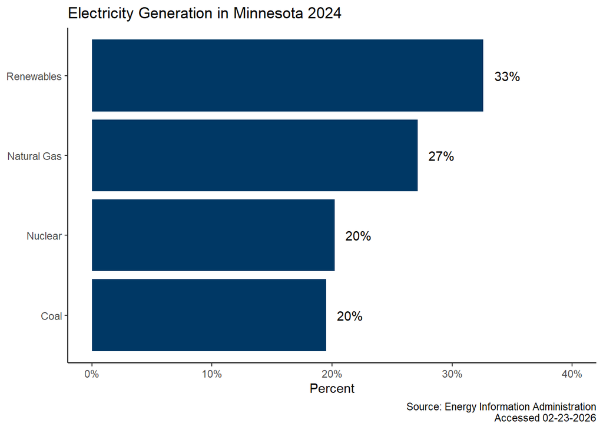

Net Generation from spreadsheet posted to https://www.eia.gov/electricity/data/state/ (appears to be updated more quickly than the API). Use to verify what gets pulled from API.

```
## # A tibble: 21 × 5
## # Rowwise:
##     year  Coal `Natural Gas` Nuclear Renewables
##    <dbl> <dbl>         <dbl>   <dbl>      <dbl>
##  1  2024 0.195         0.271   0.202      0.326
##  2  2023 0.223         0.241   0.208      0.321
##  3  2022 0.274         0.148   0.249      0.324
##  4  2021 0.266         0.216   0.239      0.272
##  5  2020 0.248         0.209   0.260      0.276
##  6  2019 0.300         0.212   0.238      0.243
##  7  2018 0.381         0.139   0.237      0.235
##  8  2017 0.388         0.114   0.237      0.254
##  9  2016 0.390         0.150   0.233      0.219
## 10  2015 0.433         0.130   0.211      0.218
## # ℹ 11 more rows
```

Change in Net Generation in Minnesota

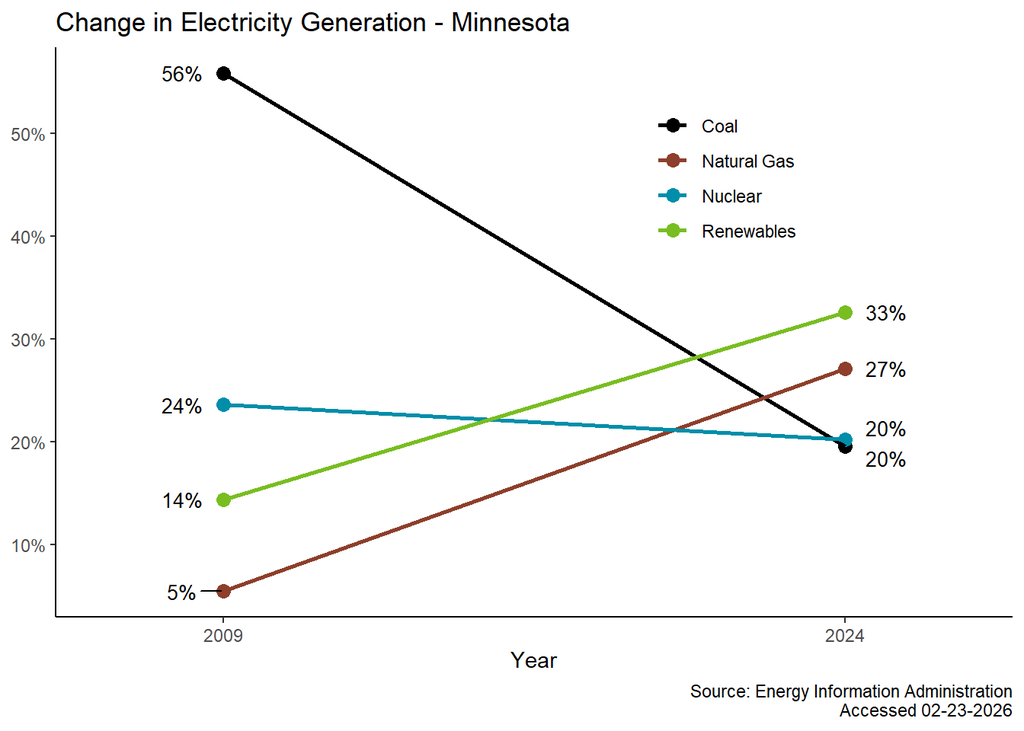

Change in US Electricity Generation

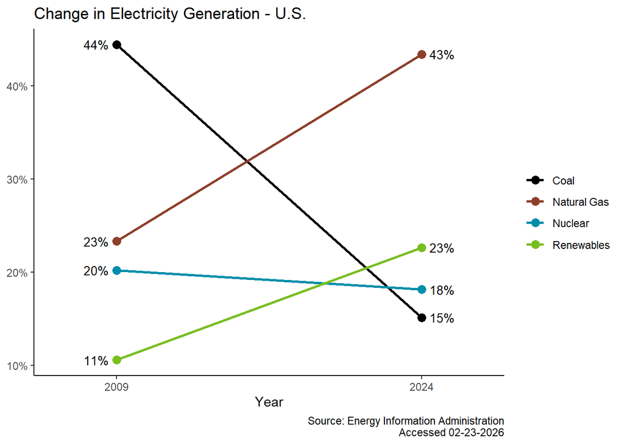

Minnesota Electricity Generation by Source (2000-Current)

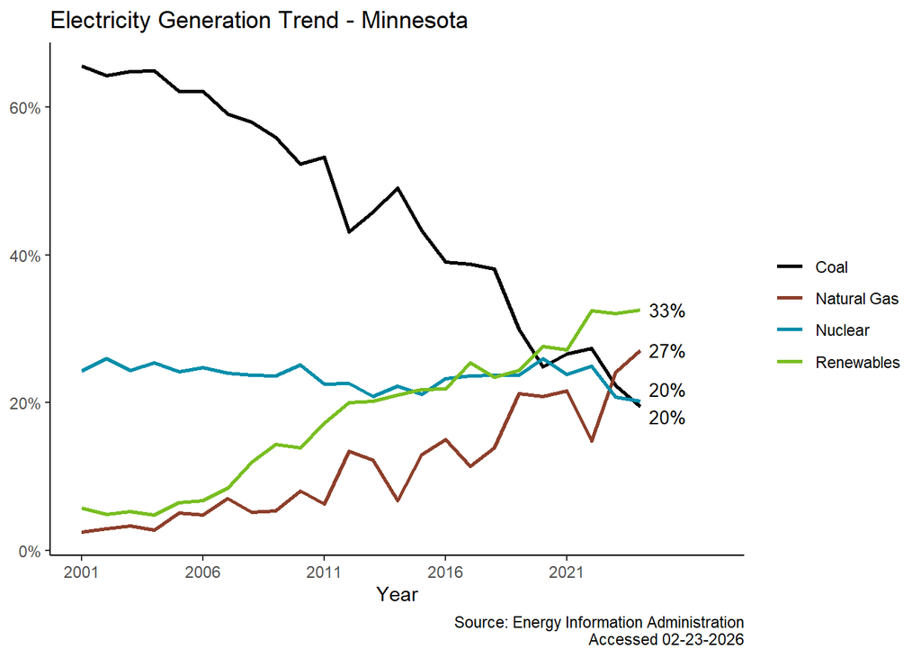

US Electricity Generation By Source

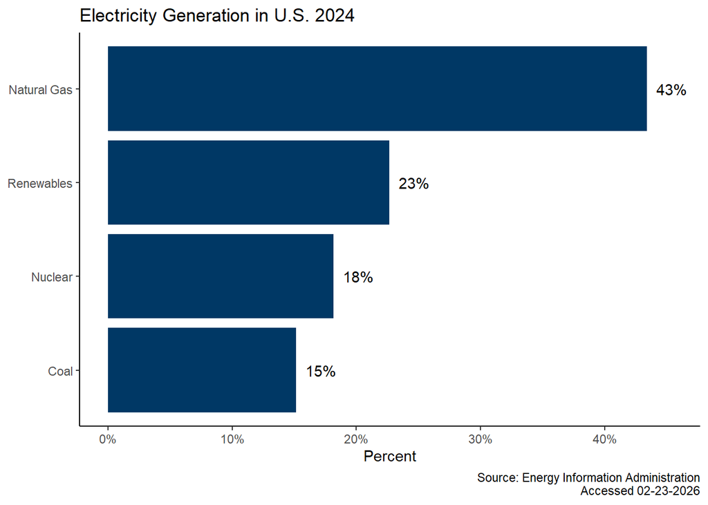

Midwest Electricity Generation By Source

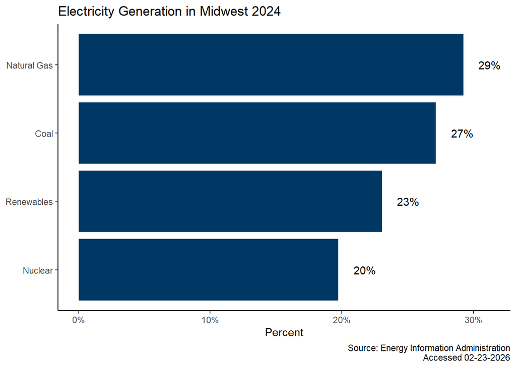

MROW Electricity Generation By Source (Hardcoding this for the Quad. See original source here: https://www.epa.gov/egrid/power-profiler#/MROW)

Coal Gas Nuclear Renewables 39.6% 10.6% 8.6% 40.7%

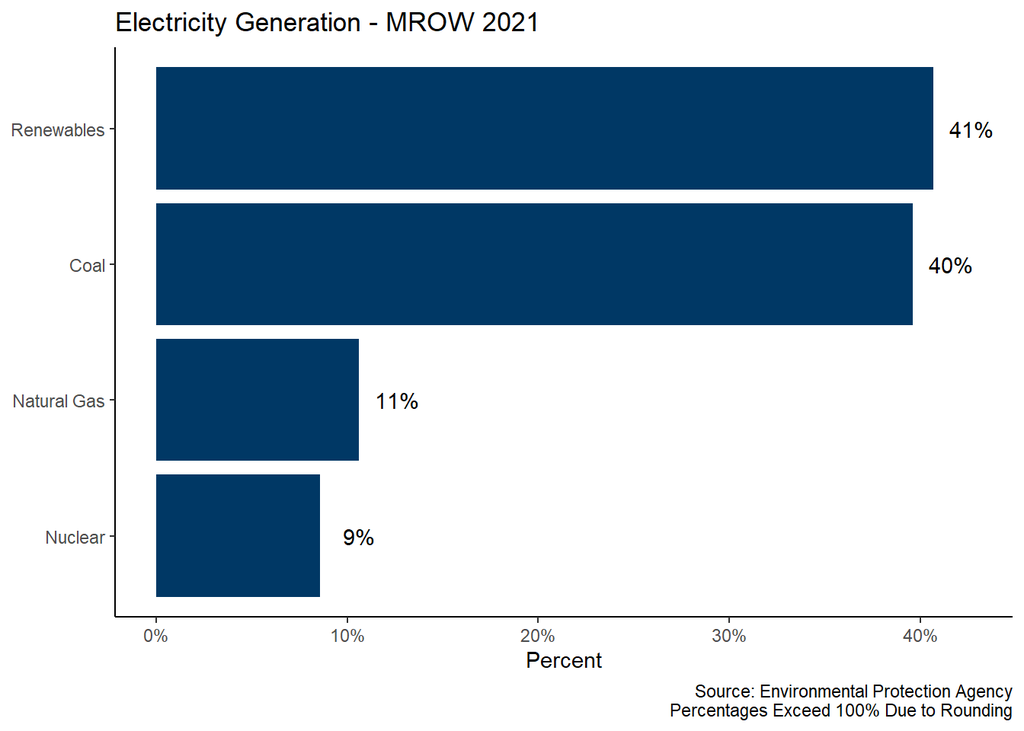

Total and Renewable Generation

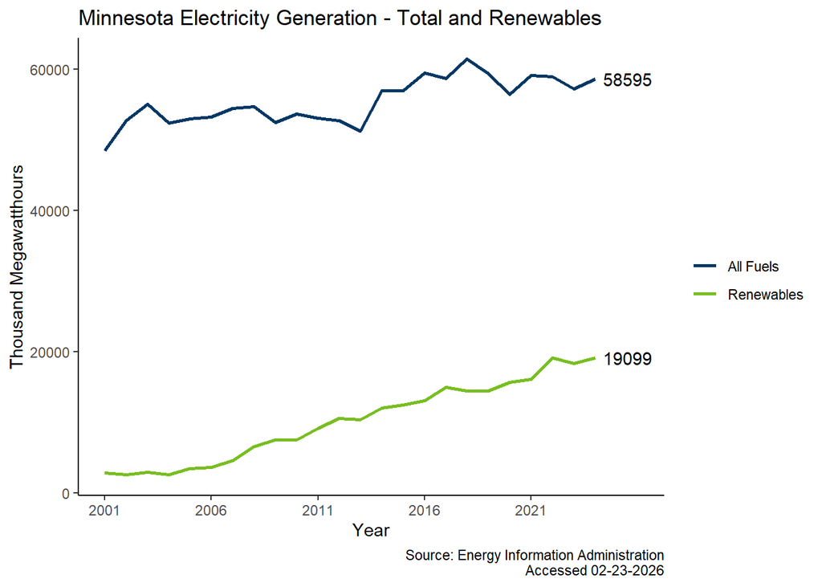

### Renewables

Renewable Energy Consumption vs Total Energy Consumption in MN

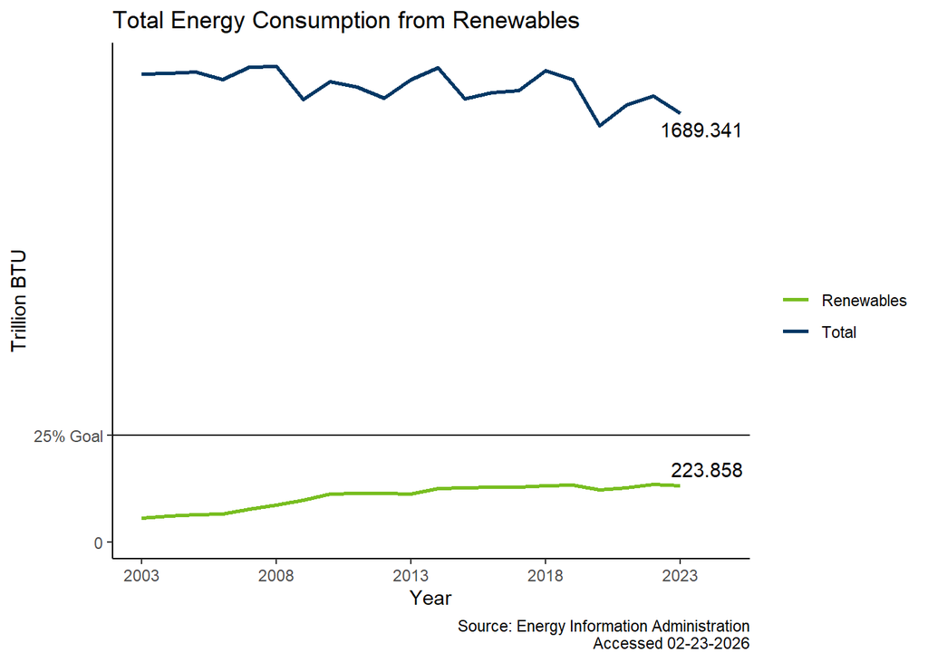

Renewable Electricity Trend

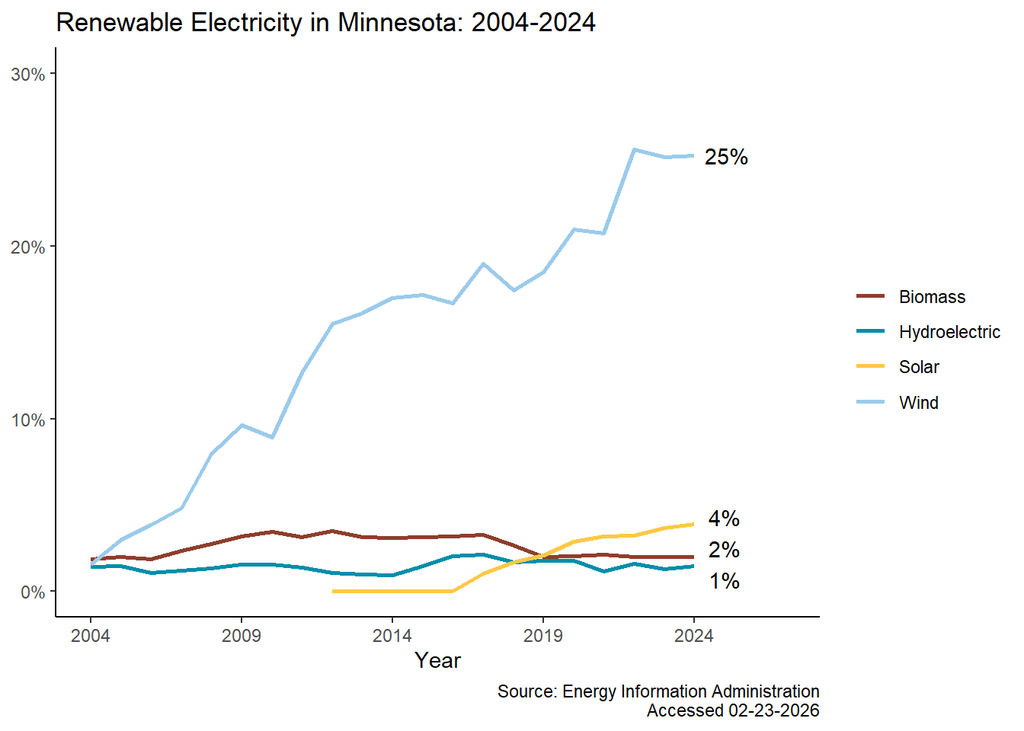

Minnesota and US Renewable Electricity Trend

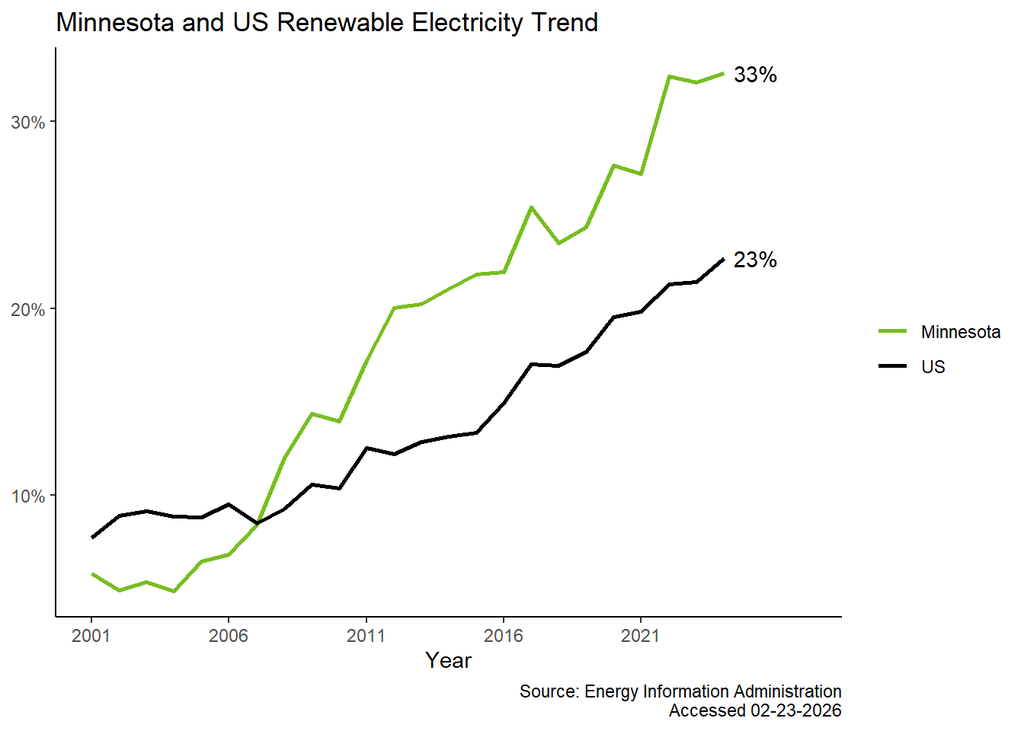

### Renewables and Coal

Percent of electricity generated by coal

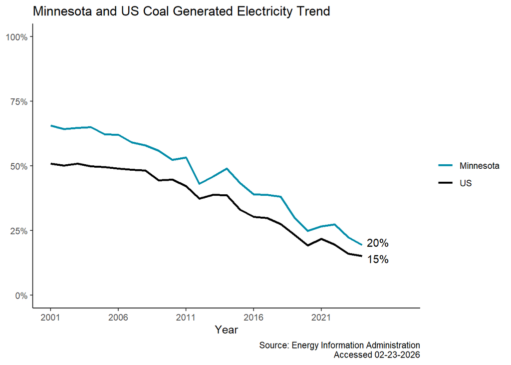

Carbon Intensity of Electricity

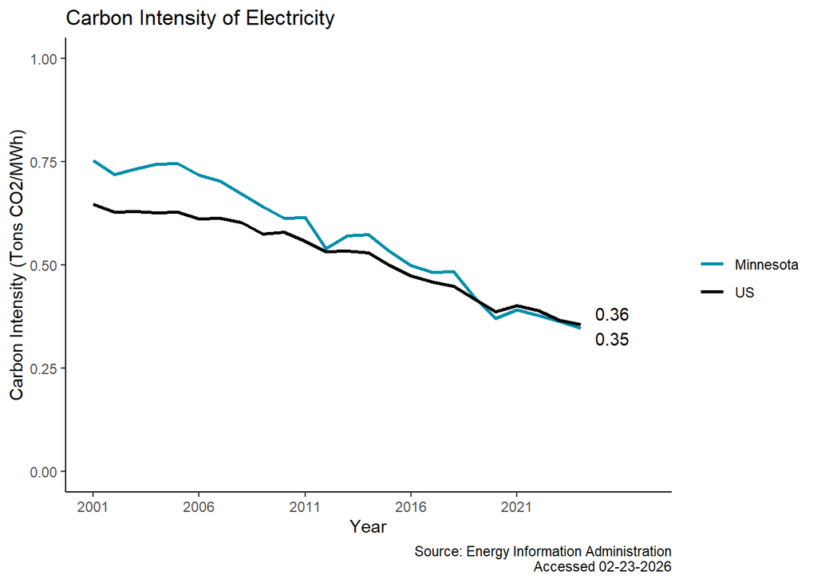

Economic and Seasonal Dispatch of Coal

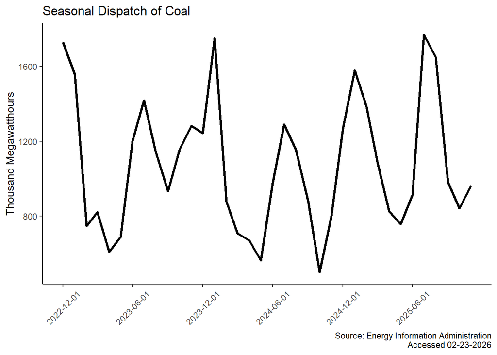

Minnesota Electricity Generation Transition

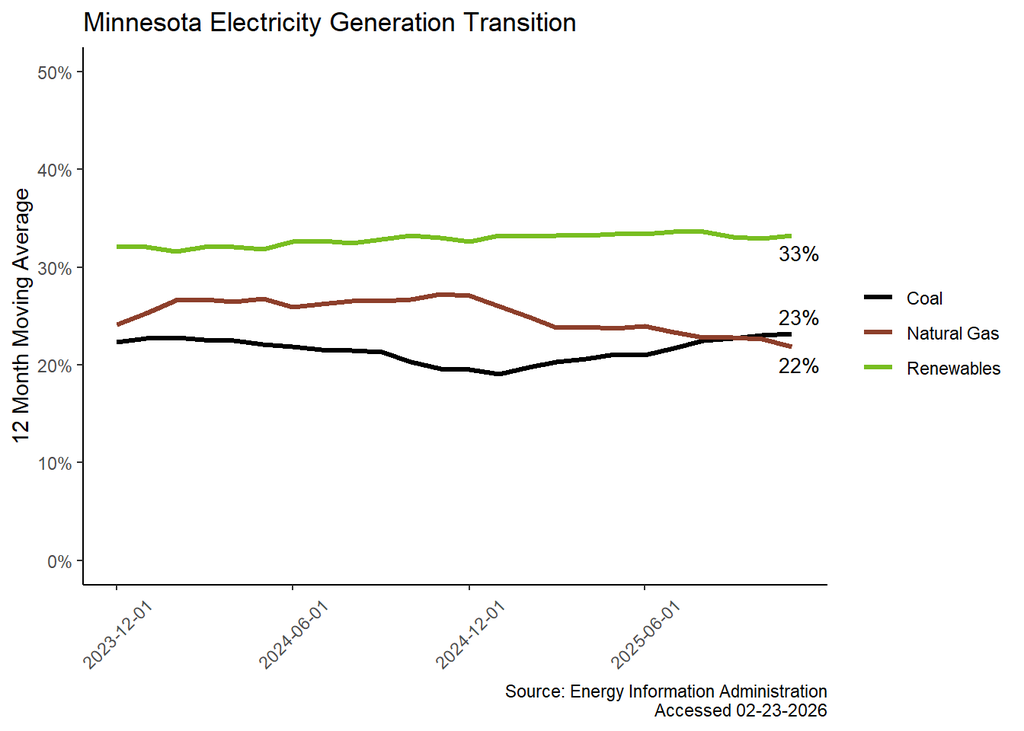

### Solar

Download comprehensive solar data

Solar data to post to the website

Solar aggregate capacity by year

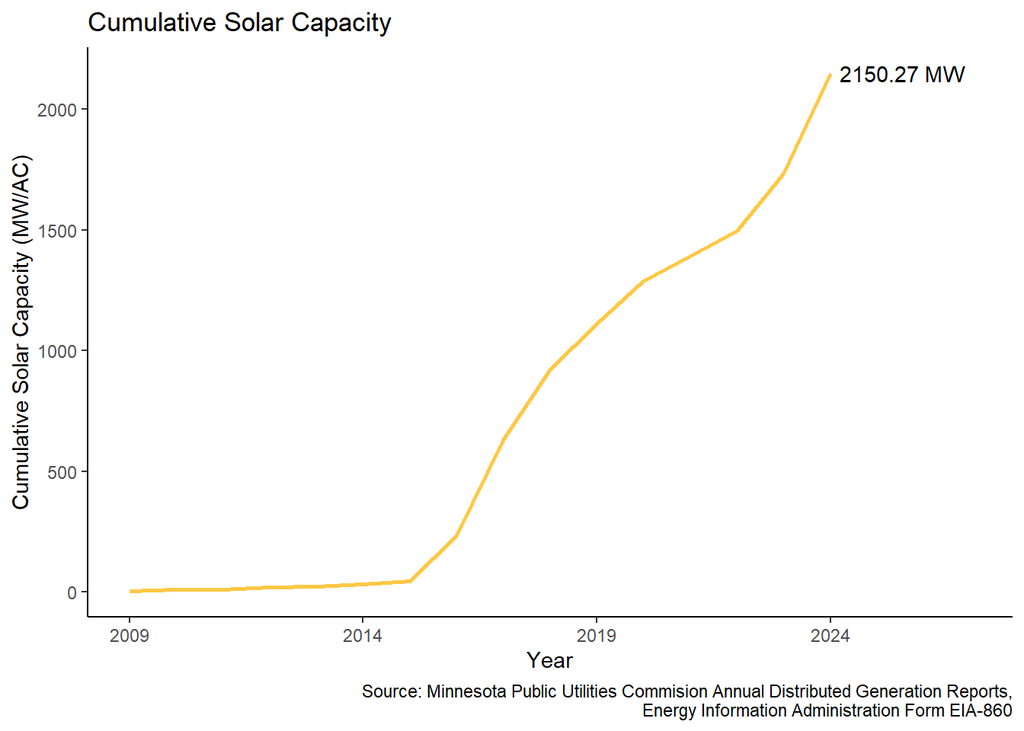

Solar Installation Type Trend

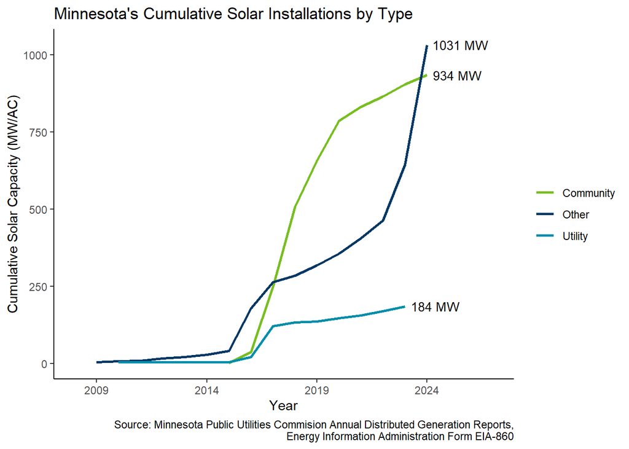

Solar Installations by year

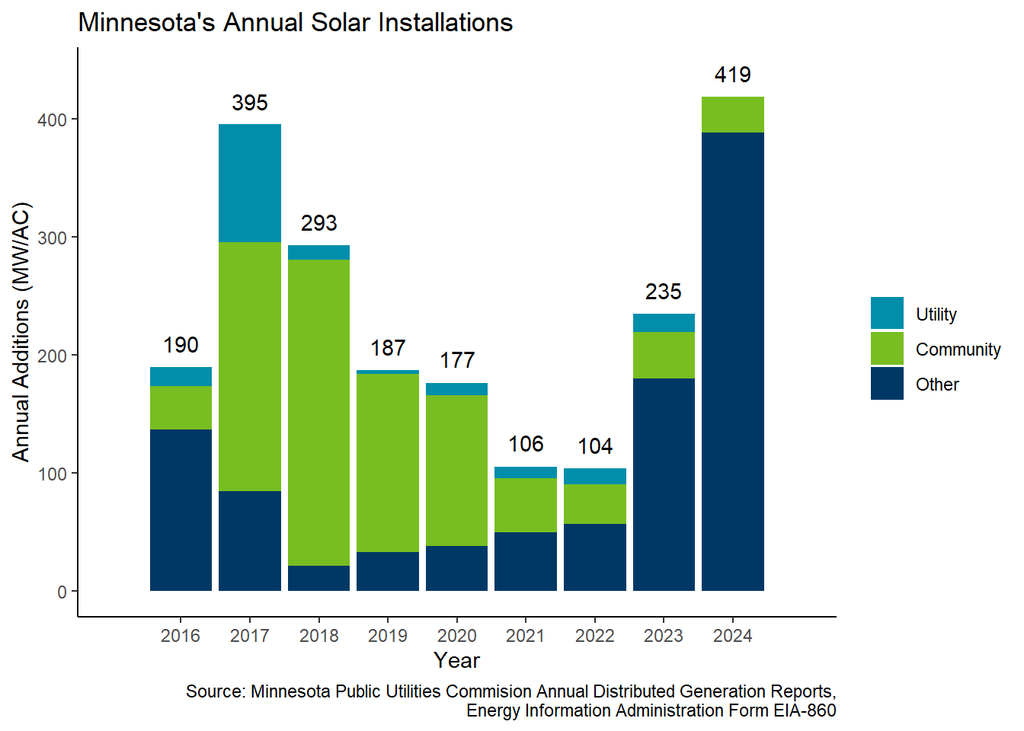

Capacity by type of solar installation

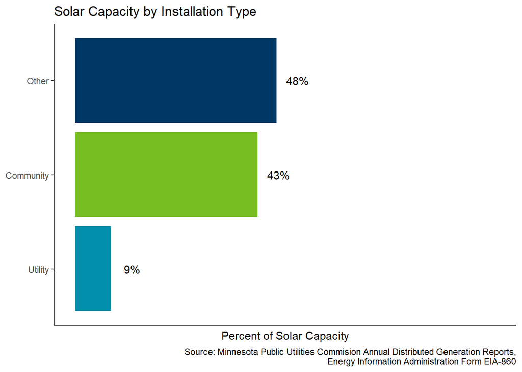

### Wind

Download Wind Data

Wind aggregate capacity by year

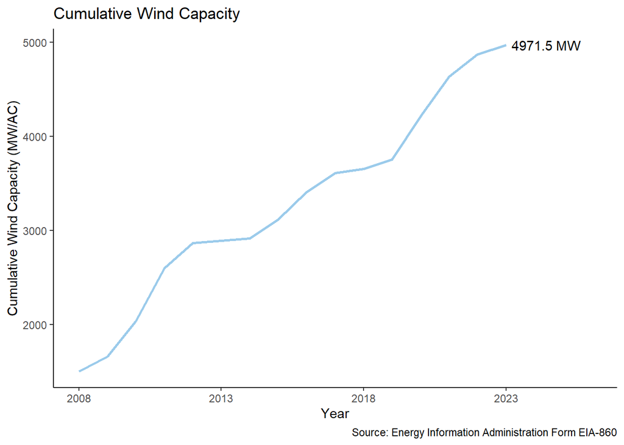

Annual Wind Installations

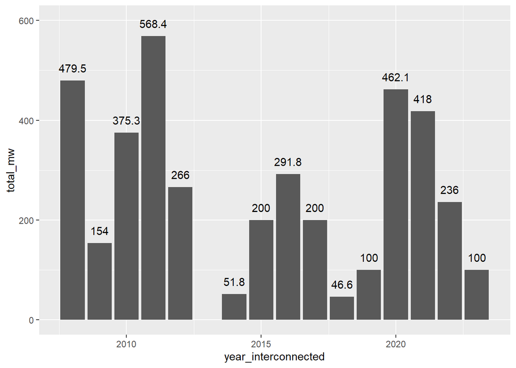

### Storage

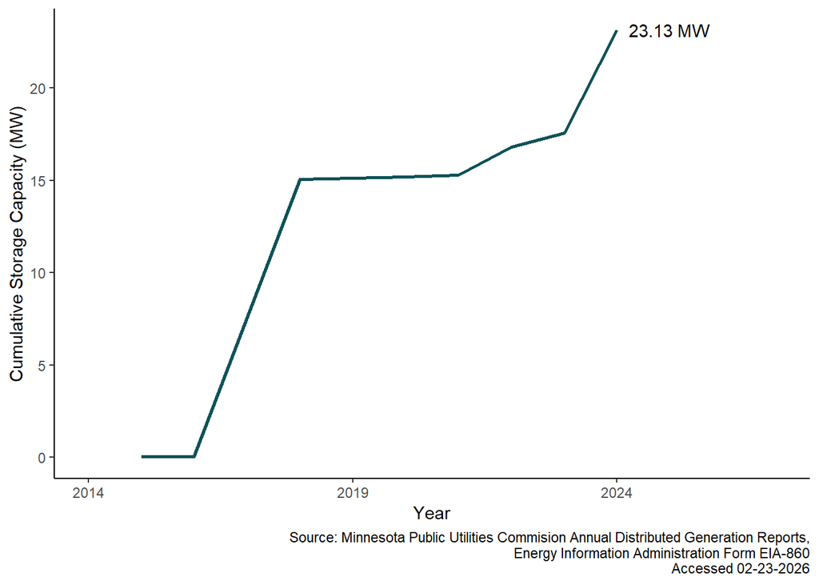

### Natural Gas

Download Monthly Henry Hub Spot Price Data

| period | product-name | value | units |
| --- | --- | --- | --- |
| 2026-01 | Natural Gas | 7.72 | $/MMBTU |
| 2025-12 | Natural Gas | 4.26 | $/MMBTU |
| 2025-11 | Natural Gas | 3.79 | $/MMBTU |
| 2025-10 | Natural Gas | 3.19 | $/MMBTU |
| 2025-09 | Natural Gas | 2.97 | $/MMBTU |
| 2025-08 | Natural Gas | 2.91 | $/MMBTU |
| 2025-07 | Natural Gas | 3.2 | $/MMBTU |
| 2025-06 | Natural Gas | 3.02 | $/MMBTU |
| 2025-05 | Natural Gas | 3.12 | $/MMBTU |
| 2025-04 | Natural Gas | 3.42 | $/MMBTU |

[output cut: 339 more lines]

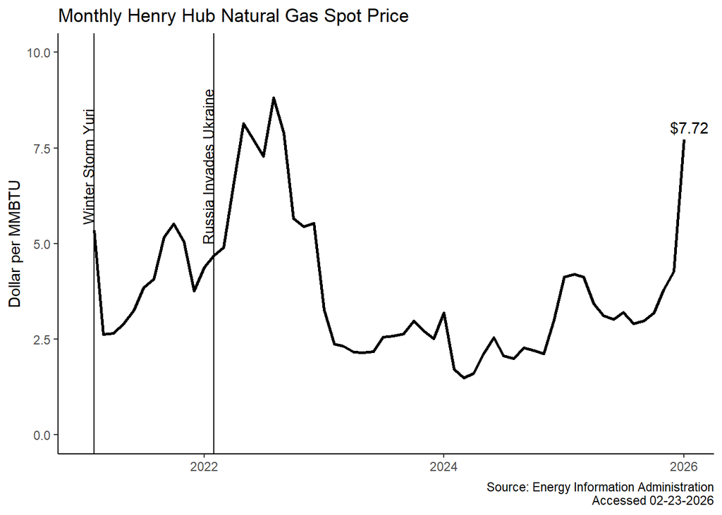

Natural Gas Electricity Generation Since 2021

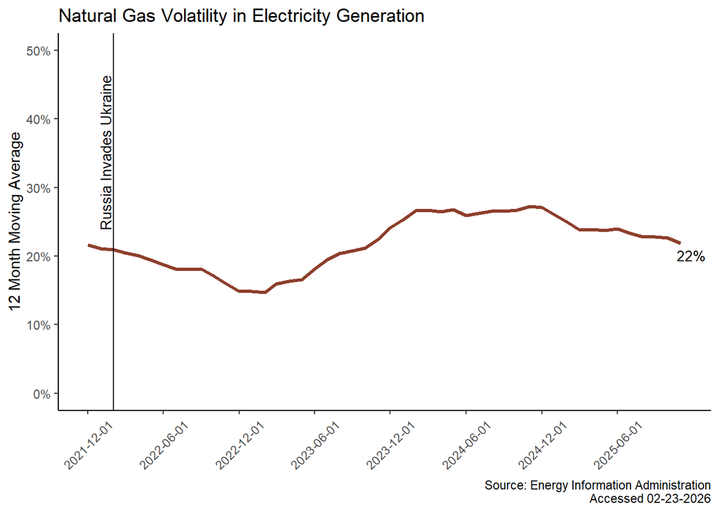

### Energy Consumption

View Energy Consumption Data

| period | fuel | Billion BTU |
| --- | --- | --- |
| 2024 | Coal | 134647 |
| 2024 | Imports | 13172 |
| 2024 | Nuclear | 123693 |
| 2023 | Coal | 148968 |
| 2023 | Imports | 88038 |
| 2023 | Natural Gas | 536789 |
| 2023 | Nuclear | 124626 |
| 2023 | Petroleum | 567064 |
| 2023 | Renewables | 223858 |
| 2023 | Total | 1689341 |

[output cut: 441 more lines]

Energy Consumption Trend

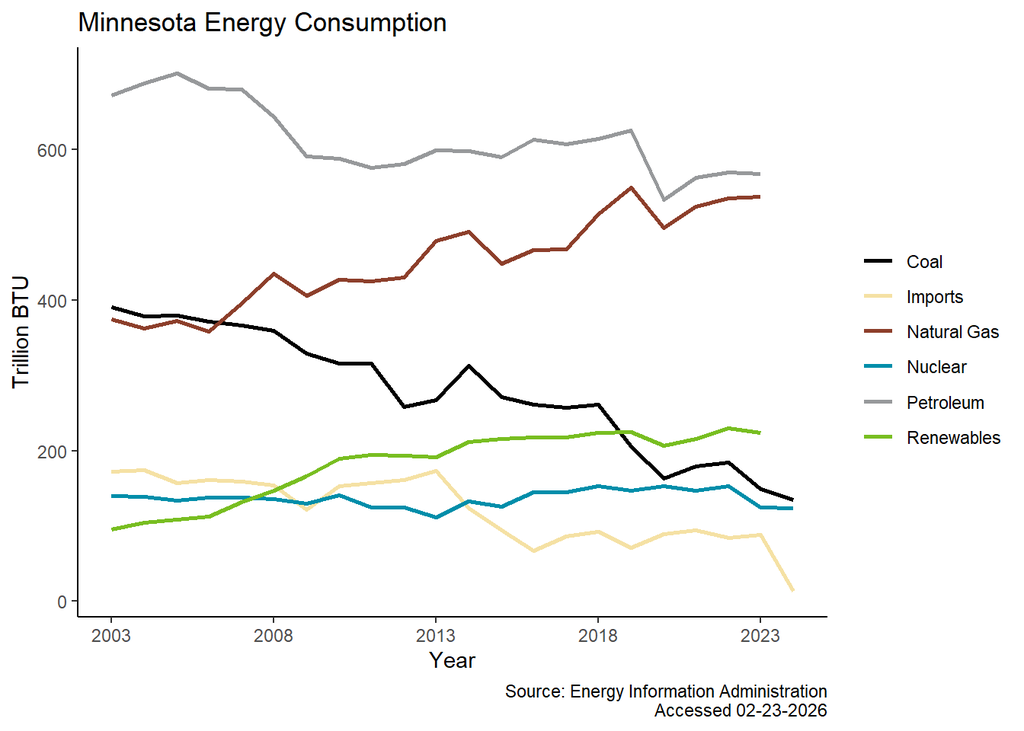

Transition of Energy Consumption

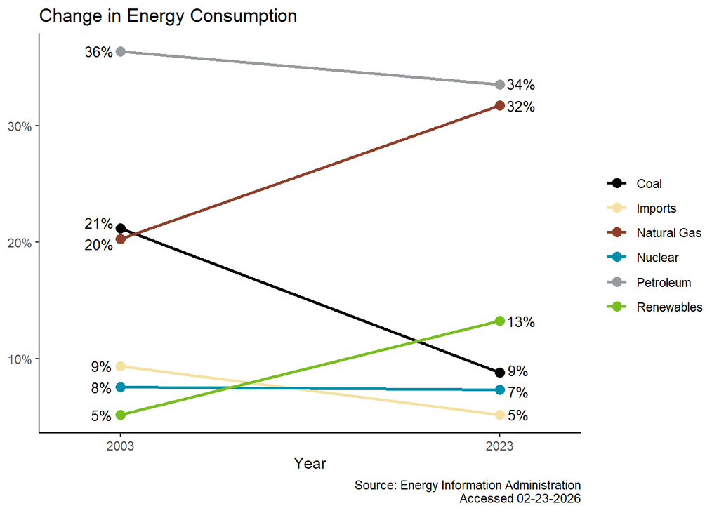

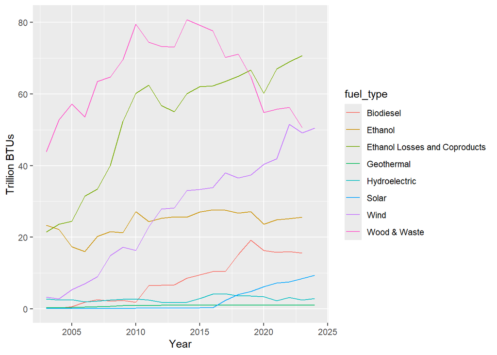

Renewables as a percent of total consumption - MN vs US

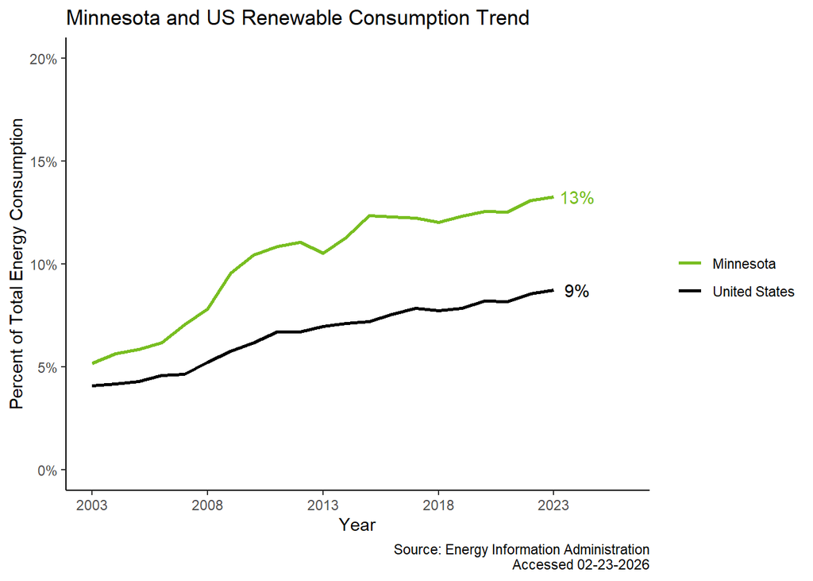

### Energy Losses

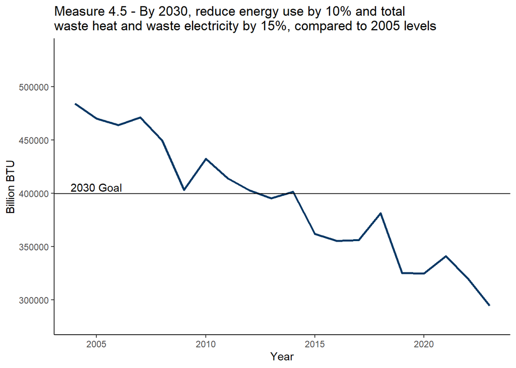